# PracticalML_project

Eric Zhang

July 27, 2017

## Introduction

Using devices such as Jawbone Up, Nike FuelBand, and Fitbit it is now possible to collect a large amount of data about personal activity relatively inexpensively. These type of devices are part of the quantified self movement - a group of enthusiasts who take measurements about themselves regularly to improve their health, to find patterns in their behavior, or because they are tech geeks. One thing that people regularly do is quantify how much of a particular activity they do, but they rarely quantify how well they do it. In this project, we are going to use data from accelerometers on the belt, forearm, arm, and dumbell of 6 participants. They were asked to perform barbell lifts correctly and incorrectly in 5 different ways.

## Data preparation and clean up

```r
library(data.table)
library(randomForest)
library(dplyr)
library(rfUtilities)
training <- read.table("https://d396qusza40orc.cloudfront.net/predmachlearn/pml-training.csv", sep = ',', header=T)
training <- tbl_df(training)
```

Cleaning dataset follows two criteria: 1. Missing data is not going to fit in the model. Therefore, any column with missing data will be excluded. 2. As indicated in the introduction part, only data from accelerometers on the belt, forearm, arm, and dumbell are used for machine learning.

```r
# we do not need columns with many missing data
fun <- function(x){sum(is.na(x))}
count <- sapply(training, fun)
complete <- training[, count<1]

# get accelarator related columns and use them plut 'classe' to get the train dataset
acc_ind <- grep("arm|dumbbell|forearm|belt", names(complete),value = T)
acc_train <- select(complete, acc_ind, classe)
acc_ind2 <- grep("kurtosis|skewness|amplitude|max|min", names(acc_train), value = T)
acc_train <- select(acc_train, -one_of(acc_ind2))
```

## Model building and cross validation

```r
rf.model <- randomForest(factor(classe) ~ ., data=acc_train, ntree=100)
rf.cv <- rf.crossValidation(rf.model, acc_train, p=0.20, n=5, seed=41, ntree=100)
```

```
## running: classification cross-validation with 5 iterations
```

```r
print(rf.cv)
```

```
## Classification accuracy for cross-validation
##
##                      A   B   C   D   E
## users.accuracy     100 100 100 100 100
## producers.accuracy 100 100 100 100 100
##
## Cross-validation Kappa = 1
## Cross-validation OOB Error = 6.370644e-05
## Cross-validation error variance = 5.276064e-09
##
##
## Classification accuracy for model
##
##                      A   B   C   D   E
## users.accuracy     100 100 100 100 100
## producers.accuracy 100 100 100 100 100
##
## Model Kappa = 0.9999
## Model OOB Error = 0.0001274129
## Model error variance = 2.840957e-09
```

As seen from the summary of the random forest model on the validation data, the model is very successful and resulted in an accuracy 100% in the cross validation test.

## Prediction on the test data set

```r
test <- read.table("https://d396qusza40orc.cloudfront.net/predmachlearn/pml-testing.csv", sep = ',', header = TRUE)
test <- tbl_df(test)
# same feature elimination process as for the training set
count2 <- sapply(test, fun)
complete_test <- test[,count2<1]
acc_ind <- grep("arm|dumbbell|forearm|belt", names(complete_test), value=T)
acc_test <- select(complete_test, acc_ind)

results <- predict(rf.model, acc_test)
results
```

```
##  1  2  3  4  5  6  7  8  9 10 11 12 13 14 15 16 17 18 19 20
##  B  A  B  A  A  E  D  B  A  A  B  C  B  A  E  E  A  B  B  B
## Levels: A B C D E
```

## Appendix: Figures

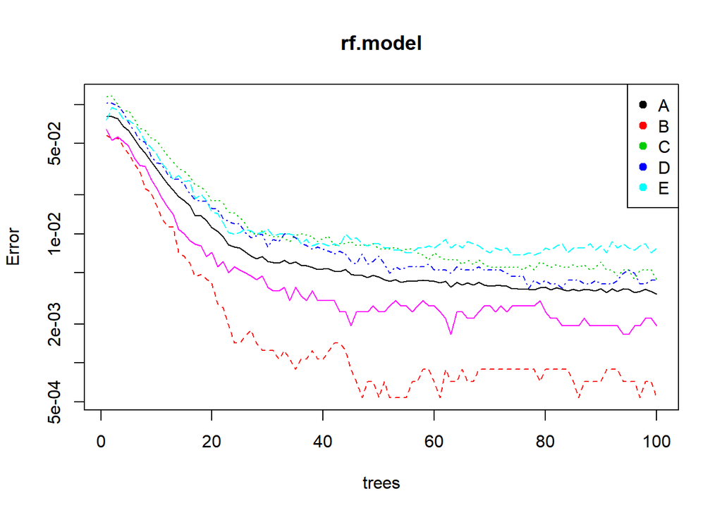

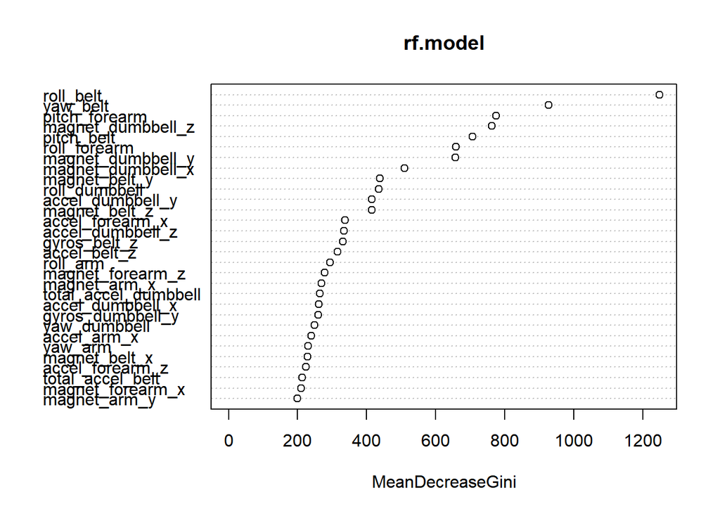